# K-Nearest Neighbors (KNN) for predicting Breast Cancer

# Tuning of KNN using Gridsearch

```python
# Paramètre GridSearchCV
k_neighbors_list = np.arange(1,30)

# Mes paramètres
search_param = {
    "n_neighbors": k_neighbors_list,
    "metric": ['euclidean', 'manhattan', 'minkowski', 'cityblock'],
    'weights': ['uniform', 'distance']
}

# Tentons d'utiser unn random Forest Classifier avec GridSearch pour trouver des paramètres optimales pour prédire
knn = KNeighborsClassifier()
grid = GridSearchCV(knn, search_param, cv = 12)
grid.fit(X_train, y_train)

# Affichons le score et les meilleurs paramètres
print("Best Score: ", grid.best_score_)
print("Best Params: ", grid.best_params_)
print("Best Estimator: ", grid.best_estimator_)
model_knn =  grid.best_estimator_
```

```
Best Score:  0.7717391304347826
Best Params:  {'metric': 'euclidean', 'n_neighbors': 14, 'weights': 'uniform'}
Best Estimator:  KNeighborsClassifier(algorithm='auto', leaf_size=30, metric='euclidean',
                     metric_params=None, n_jobs=None, n_neighbors=14, p=2,
                     weights='uniform')
```

*Nous voyons que nous avons trouver un score supérieur à notre recherche manuel. Nous gardons désormais nos meilleurs paramètres*

```
- {'metric': 'euclidean', 'n_neighbors': 14, 'weights': 'uniform'}
```

#### Methode Naïve

```python
# Prédict
#--------
y_pred_knn = model_knn.predict(X_test)

# Matrix de confusion
#--------------------
def confusion(y_true = y_test, y_pred = y_pred_knn, labels = [1,2]):
    conf_m = confusion_matrix(y_true = y_test, y_pred = y_pred_knn, labels = labels)  # [[TN, FP], [FN, TP]]
    print('-----------------')
    print(f'confusion matrix:\n{conf_m}')
    TN = conf_m[0,0]
    FP = conf_m[0,1]
    FN = conf_m[1,0]
    TP = conf_m[1,1]
    print('-----------------')
    print(f'sensitivity:{TP/(TP+FN)}')
    print('-----------------')
    print(f'specificity:{round(TN/(TN+FP),2)}')

# Call the function
#------------------
confusion()
```

```
-----------------
confusion matrix:
[[ 8  3]
 [ 0 13]]
-----------------
sensitivity:1.0
-----------------
specificity:0.73
```

#### Scikit Learn methode

```
-----------
Score_train: 0.7608695652173914
-----------
Score_test: 0.875
----------------------------------------------------------------------------
Classification report:               precision    recall  f1-score   support

           1       1.00      0.73      0.84        11
           2       0.81      1.00      0.90        13

    accuracy                           0.88        24
   macro avg       0.91      0.86      0.87        24
weighted avg       0.90      0.88      0.87        24

----------------------------------------------------------------------------
Confusion Matrix:
----------------
```

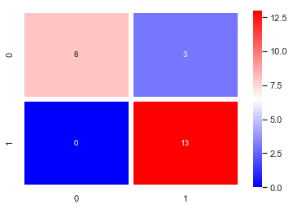

```python
# Prédict
#--------
y_pred_knn = model_knn.predict(X_test)

# Performance metrics
#--------------------
print('-----------')
print("Score_train:", model_knn.score(X_train,y_train))
print('-----------')
print("Score_test:", model_knn.score(X_test,y_test))
print('----------------------------------------------------------------------------')
print("Classification report:", classification_report(y_test,y_pred_knn))
print('----------------------------------------------------------------------------')
print("Confusion Matrix:")
print('----------------')
confusion_matrix_knn = confusion_matrix(y_test,y_pred_knn)
sns.heatmap(confusion_matrix_knn, cmap = 'bwr',
                                annot = True,
                                linewidths = 5,
                                linecolor = 'white'
                                )
plt.show()
```

*- Géniale! On n'est passé d'une précision de 75% à 88%..*

- On est bon ;-)

#### Comparons les actuels (True) avec les prédits

```python
# Nous savons que nous avons 24 valeurs donc en terme d'affichage le display sera OK
# Si on veut limiter l'affichage : y_test.values[0:n_valeurs]
print('True:', y_test.values)
print('Pred:', y_pred_knn)
```

```
True: [1 2 2 1 1 2 2 2 2 2 1 1 2 1 1 2 1 2 2 2 1 1 1 2]
Pred: [1 2 2 1 2 2 2 2 2 2 1 1 2 1 1 2 2 2 2 2 1 1 2 2]
```

**Conclusion:**

- *On peut voir que 3 fois notre modèle a prédit 2(has_cancer) au lieu de 1(healthy) qui est l'actuel : faux positif*
- *On peut voir que 8 fois notre modèle a prédit 1(healthy) qui est l'actuel : vrai negatif*
- *On peut voir que 0 fois notre modèle ne s'est trompé sur le : faux négatif*
- *On peut voir que 13 fois notre modèle a prédit 2(has_cancer) qui est l'actuel : vrai positif*